# Wine predictor graphical analysis

7/29/2019

## Project Assignment Synopsis

### Build web application using Rstudio's shiny package and deploy to shiny server

### Include documentation to describe application

Application must take user input , use that input to perform and output some analysis

Create a slide presentation to describe the web application (this presentation)

## Approach

This analysis uses the 'wine' data-set which is in the 'rattle' package The data set describes 178 observations of 13 characteristics of wines which can be used to predict the 'type' which is a coded response of 3 levels. The data description is located at https://rdrr.io/cran/rattle.data/man/wine.html

### The web application is published to https://arairkar.shinyapps.io/ddp-week4/

## Web application architecture

### Descriptors: Describe what the application is doing

### Input

Filter the column names from the wine data set except for reponse column1 'Type' Present list of columns to user for selection

### Output

1. The name of the column selected for analysis
2. A scatter plot with box plots of Type by selected column
3. The subset table of Type and selected column

Note: Ideally, a nominal logistic regression should be performed for Type (a discrete response) Vs Selected column ( a numeric factor). This is proposed as future work.

## Example output for 'Color' factor

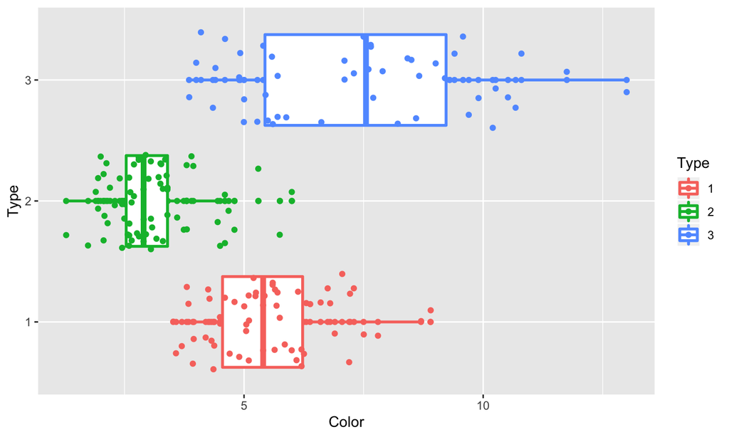